# Unexpected distribution of subordinates around nests of the wood ants - ScienceDirect

## Figures (2)

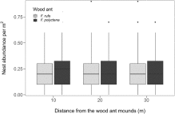

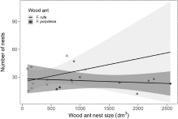

## Tables (2)

1. Table 1
2. Table 2

## Extras (1)

1. Multimedia component 1

## [Acta Oecologica](https://www.sciencedirect.com/science/journal/1146609X)

[Volume 110](https://www.sciencedirect.com/science/journal/1146609X/110/supp/C), May 2021, 103709

# Unexpected distribution of subordinates around nests of the wood ants

[I.E.Maák<sup>a</sup><sup>d</sup>](https://www.sciencedirect.com/science/article/pii/S1146609X21000084#!)[I.Sondej<sup>b</sup>](https://www.sciencedirect.com/science/article/pii/S1146609X21000084#!)[O.Juhász<sup>a</sup><sup>c</sup>](https://www.sciencedirect.com/science/article/pii/S1146609X21000084#!)[G.Trigos-Peral<sup>d</sup>](https://www.sciencedirect.com/science/article/pii/S1146609X21000084#!)[A.Tenyér<sup>a</sup>](https://www.sciencedirect.com/science/article/pii/S1146609X21000084#!)[J.Camera<sup>e</sup>](https://www.sciencedirect.com/science/article/pii/S1146609X21000084#!)[W.Czechowski<sup>d</sup>](https://www.sciencedirect.com/science/article/pii/S1146609X21000084#!)

https://doi.org/10.1016/j.actao.2021.103709[Get rights and content](https://s100.copyright.com/AppDispatchServlet?publisherName=ELS&contentID=S1146609X21000084&orderBeanReset=true)

## Highlights

**•**

Competitive effects of two territorial wood ants, *Formica rufa* and *F. polyctena,* were studied.

**•**

Nests of subordinate ants had an even diversity, density and distribution close-by the mounds.

**•**

Species-specific negative effects can be related to mound size differences among the two wood ants.

**•**

Subordinate species might tolerate the circumstances close-by the mounds due to their adaptability.

**•**

Adaptations may allow the subordinates to survive while maintaining relatively large nest densities.

## Abstract

The hierarchical organization of multi-species ant communities can be determined by the colony size and worker density-dependent differences in behaviour, recruitment efficiency, and aggressiveness between colonies of different species. In this study, we compared the competitive effects of two territorial wood ant species, *Formica rufa* and *F. polyctena*, on the ant species subordinated to them (encounterers and submissives) that nest close-by their mounds. The nests of subordinates were mapped in 10 m<sup>2</sup> plots around the mounds of each of the two wood ant species, situated at a distance of 10, 20 and 30 m in four directions. The most abundant subordinate species were two *Myrmica* species: *M. rubra* and *M. ruginodis.* Interestingly, the nests of subordinates had an even diversity, density and distribution along with the distance from the wood ant mounds. The wood ant presence had a species-specific negative effect on some of the subordinate species, which can be in relation with the smaller mound sizes in *F. rufa* compared to *F. polyctena.* Based on our results it seems that subordinate species, due to their adaptability, might tolerate the circumstances close-by the wood ant mounds by changes in their strategies, foraging behaviour, and switching to the use of alternative food sources, like corpses of wood ants present in high abundance. Although these might not allow reaching normal colony size and reproduction, they may allow the colonies to survive while maintaining relatively large nest densities.

## Keywords

Distance from mounds

*Formica polyctena*

*Formica rufa*

*Myrmica*

Nest density

## 1. Introduction

Interspecific competition (mainly for food sources and nesting places) plays an important role in shaping ant communities in temperate regions (Reznikova, 1982; Savolainen and Vepsäläinen, 1988; Savolainen et al., 1989; Punttila et al., 1996; Braschler and Baur, 2003; Sanders and Gordon, 2003; Adler et al., 2007; Cerdá et al., 2013; Czechowski et al., 2013). Differences in behaviour, recruitment efficiency and aggressiveness that depend on colony size and worker density are reflected in a hierarchical organization of multi-species ant communities (Savolainen et al., 1989; Cerdá et al., 2013). According to the concept of K. Vepsäläinen and B. Pisarski (Vepsäläinen and Pisarski, 1982; Pisarski and Vepsäläinen, 1989), the hierarchy consists of three main competition levels. The highest level is constituted by territorial species whose colonies defend (in addition to their nests) their entire foraging areas against foreign conspecific colonies and colonies of other territorial species. The two lower levels are created by species subordinate to territorials: intermediate level by encounter species, which defend against competitors, in addition to the nests, also their food sources, and the lowest level by submissive species, which defend only their nests and yield to stronger competitors in all other conflict situations.

The higher the ant species’ position in the hierarchy, the stronger its impact on species with lower hierarchic status. As a rule, territorials exclude each other and significantly limit the nesting ability of encounterers (Hölldobler and Wilson, 1977; Savolainen and Vepsäläinen, 1988; Savolainen et al., 1989; Markó and Czechowski, 2004; Cerdá et al., 2013; Czechowski et al., 2013; Markó et al., 2013; Ślipiński et al., 2014; Adams, 2016). The possibility of co-occurrence of different ant species is also context-dependent, determined by several other factors like climatic conditions, habitat structure, distribution and properties of food sources, the presence of parasites and predators, etc. (Davidson, 1977; Vepsӓlӓinen, 1978; Levings and Traniello, 1981; Savolainen et al., 1989; Savolainen and Vepsäläinen, 1989; Markó and Czechowski, 2004; Czechowski and Vepsäläinen, 2009; Gibb, 2011; Cerdá et al., 2013; Czechowski et al., 2013; Adams, 2016; Stuble et al., 2017).

Competition unavoidably occurs when the ecological requirements of species overlap (Pianka, 1974; Glen and Dickman, 2008). The negative effects of competitive interactions can be weakened if the morphological adaptations and/or behavioural and ecological plasticity of the competing partners allow shifts in their needs, thus reducing niche overlap, which is observed also in ants (see Cerdá et al., 2013 for a review). On the other hand, in ants, the most effective strategy to ensure the control of resources, and thus an advantage over competitors is territoriality (Hölldobler and Wilson, 1990; Adams, 2016). Territorial ants dominate their foraging areas, exerting stronger or weaker pressure on the cohabiting ant species (Savolainen and Vepsäläinen, 1988); in general, the more competitive a species to a dominant, the further the former can nest from the latter (Savolainen and Vepsäläinen 1988, 1989; Czechowski et al., 2013; Adams, 2016; Trigos-Peral et al., 2016; Ślipiński et al., 2018).

Clear division of food resources contributes to the decrease in competitive pressure (Levings and Traniello, 1981; Sorvari and Hakkarainen, 2004). The cohabitation of two morphologically similar species can be ensured by behavioural differences: while a species can dominate in contest competition due to its aggressive behaviour, the other can adjust its foraging strategy by being faster in retrieving the prey and/or more efficient in discovering food supplies (Reznikova, 1982; Savolainen, 1991; Gordon, 2010). Under stable circumstances, a lower-ranked species can cohabit with a species of a higher level, but when supplies diminish, the competition between them increases to a degree that prevents further coexistence (Savolainen and Vepsäläinen, 1988; Markó and Czechowski, 2004; Cerdá et al., 2013; Czechowski et al., 2013; Markó et al., 2013; Ślipiński et al., 2014).

The North-Palaearctic (including boreo-montane) species of the *Formica rufa* group are highly aggressive territorial ants that can often develop multi-nest polydomous systems (interrelated nests formed by colony fissions), with possible worker, queen, brood and information exchange in-between (Czechowski et al., 2012; Stockan and Robinson, 2016; Seifert, 2018). In temperate forest ecosystems, wood ants of the *F. rufa* group are the most common top dominants of the ant communities, which makes them the main structuring factor for these communities; they have a strong influence on the composition, distribution and density of other ant species (Savolainen et al., 1989; Savolainen et al., 1989; Czechowski and Vepsäläinen, 2001; Czechowski and Markó, 2006; Väänänen et al., 2010; Stukalyuk, 2015) and can lower their fitness and modify their activity and foraging habits (Savolainen, 1990, 1991; Czechowski and Markó, 2005). Within their territory, they usually exclude other strong competitors, but the submissive species can occur in quite high density (Savolainen and Vepsäläinen, 1989; Czechowski and Markó, 2005; Väänänen et al., 2010; Stukalyuk, 2015; Seifert, 2018). Along with the increasing distance from their nests, the abundance of other species may increase proportionally (Savolainen and Vepsäläinen, 1989). Despite fairly large knowledge about the competitive effect of the territorial wood ants on other ant species, there is still a lack of a detailed comparison of the impact of colonies of different wood ants species on the nesting habits of their subordinates (encounterers and submissives).

In this study, we investigated the small-scale effect of two wood ant species of the *F. rufa* group, namely *F. rufa* and *F. polyctena*, on local communities of the subordinate ant species. We hypothesized that the differences in the characteristics of each of these two territorials (see below) will be reflected in the patterns of occurrence of the subordinates, especially submissive species that can be more than encounterers tolerated by wood ants in close vicinity of the mounds of the latter. We expected the nest density of the submissives to be negatively correlated with the mound size (as a relative measure of the wood ant colony size). The difference in the mound size will be reflected in the different activity of wood ant workers within their territory, which in turn will influence the density of nests of other species. We also expected that the increasing distance from the wood ants’ mounds will have a positive effect on the nest density of the subordinate, mostly encounter species, as the impact of wood ants on these species is expected to be higher than on the submissives.

## 2. Material and methods

### 2.1. Study species

*Formica rufa* Linnaeus 1761 and *F. polyctena* Förster 1850 are North-Palaearctic oligotopes (species occurring in habitats of a few similar types, or species that demand a specific physical habitat factor, irrespective of the general type of vegetation, see Czechowski et al., 2012) of temperate and sub-mountain coniferous and mixed forests, met also in deciduous forests (Czechowski et al., 2012; Seifert, 2018). Both *F. rufa* and *F. polyctena*, as fairly thermophilic species, they occur mainly in sunny places, on glades, forest edges and along forest roads, although they are also found in shady places deep in the forest (*F. rufa* less often, *F. polyctena* more often). They build nests with impressive mounds of dry plant particles (coarser in *F. rufa*, finer in *F. polyctena*); in *F. rufa*, the diameter of the mound may exceed 1 m, in *F. polyctena*, even 3 m (Czechowski et al., 2012; Seifert, 2018). Like all wood ants, they forage in all forest layers, from the roots, through the ground to tree canopies, as honeydew collectors, scavengers and non-selective predators against a variety of invertebrates. Having similar habitat requirements and biology, these two species differ in structure and social organization. Colonies of *F. rufa* in continental Eurasia are usually monogynous, i.e. one-queened (in the British Isles, they are usually polygynous), and thus monodomous; their sizes reach several hundred thousand workers. In contrast, colonies of *F. polyctena* (absent from the British Isles) are generally highly polygynous (up to a few thousand queens in one nest), and frequently number over a million workers. Due to polygyny, they often form extensive multi-nest (polydomous) systems (Collingwood, 1979; Czechowski et al., 2012; Seifert, 2018).

### 2.2. Study area and sampling design

We carried out the fieldwork in the managed part of the Białowieża Forest (52°41.891′N, 23°53.477′E; N-E Poland) near the border with Belarus in July 2017. The tree stands of the studied mixed forest consisted mainly of the pedunculate oak (*Quercus robur*), Norway spruce (*Picea abies*), Scots pine (*Pinus sylvestris*), silver birch (*Betula pendula*) and hornbeam (*Carpinus betulus*) (Sokołowski, 2004). The age of the pine and spruce trees varies between 32 and 180 years (Forest Data Bank). The annual mean air temperature and precipitation are 6.8 °C and 633 mm, respectively (Pierzgalski et al., 2002). Fawn-brown podzolized soil and different types of rusty brown forest soils are representative for the area (Forest Data Bank).

Around each of the selected wood ant mounds, we marked out four transects in the directions S, W, N and E. On each of the transects, we established three square plots with an area of 10 m<sup>2</sup> (approx. 3.16 × 3.16 m); a total of 12 plots per mound, at 10, 20 and 30 m from the mound. The distance was measured from the edge of the mound to the centre of the given quadrat. Within every plot, we mapped the number of ant nests, their exact location within the quadrat and their distance from each other, and the presence of wood ant workers (foraging trails or dispersed individuals). If the latter were present, we considered that plot with high wood ant presence (WA+), whereas when no wood ants were found, that plot was considered with low wood ant presence (WA–). A sample for species identification was taken from each found nest. Ants, both those of the subordinate species and (earlier) of the wood ant species were identified by using the keys of Seifert (2007) and Czechowski et al. (2012). Voucher specimens are deposited in the Museum and Institute of Zoology, Polish Academy of Sciences, Warsaw.

### 2.3. Data analysis

The total number of subordinate ant nests per species found within the territories of *F. rufa* and *F. polyctena* were compared with paired Wilcoxon test (N = 13). We also calculated the Shannon Wiener entropies for the territories of each of the two wood ant species based on the total number of subordinate ant nests of different species.

To compare the sizes of the mounds of each of the two wood ant species we used a general linear model (GLM, Gaussian error, maximum likelihood fit). In the model, the species ID was included as an explanatory factor (N = 20). The effect of the mound size, the wood ant species and their interaction on the total number of subordinate ant nests within the wood ant territories were also analysed with GLM (Gaussian error, maximum likelihood fit, N = 20). In the model, the species ID was included as an explanatory factor, whereas the wood ant mound size and their interaction as covariates.

The effect of the wood ant species (*F. rufa* and *F. polyctena*), the distance from the wood ant mound and the wood ant worker presence within the plots (WA–, WA+) on the number of nests found within the plots was tested with GLMM (Poisson error, maximum likelihood fit, N = 240). In the model, the wood ant species, the wood ant worker presence (WA-/WA+), the distance and the interaction of the two latter were included as explanatory factors, whereas the nest mound ID was included as a random factor (N = 240). Separate models were built for the number of all the nests found within the study plots, of the nests belonging to the genus *Myrmica*, of the nests of other species than those of the genus *Myrmica*, and of the nests of each of the two most abundant *Myrmica* species, i.e. *M. rubra* and *M. ruginodis*. The same model construction (GLMM, Poisson error, maximum likelihood fit, N = 240) was used to test the effect of the wood ant species, the wood ant worker presence (WA-/WA+), the distance from the wood ant mound and the interaction of the two latter on the number of ant species found in the different plots. The best models were selected with automated model selection.

The relationship between the total number of nests found in plots at different distances (10, 20, 30 m) and directions (S, W, N, E) from the wood ant mounds was analysed using the Chi<sup>2</sup> test. The total number of nests found in the different plots were summed up according to the different distances and directions.

If necessary, the variables were log-transformed prior to the analyses to meet the normality and homogeneity of variances. In model overdispersion, a negative binomial error structure was applied (see Lindén and Mäntyniemi, 2011). Statistical analyses were carried out in R Statistical Environment (R Core Team, 2019). GLMs were performed using the *‘glm’* function, whereas Chi<sup>2</sup> analysis was performed using the ‘*chisq.test*’ function from the *Stats* package. GLMMs were performed using the ‘g*lmer*’ function from the *lme4* package (Bates et al., 2013). Automated model selection was carried out with the help of the *dredge* function in the *MuMIn* package (Bartoń, 2019). The ‘*emmeans*’ function (*emmeans* package) was used for sequential post-hoc comparisons among factor levels when performing GLMM analyses (Russell, 2019).

## 3. Results

Table 1. The number of nests belonging to different subordinate ant species found on the territories of the two wood ants (*F. rufa* and *F. polyctena*) at different distances from the mounds, their total numbers depending on the wood ant species and the total number of nests found in different subordinate species.

[output not shown]

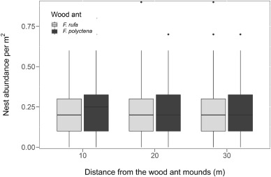

Fig. 1. The nest density of all the subordinate ant species found within the territories of *F. polyctena* (dark grey) and *F. rufa* (light grey) in the plots at different distances from the mounds (medians, quartiles, min-max values and outliers).

Mound volumes (in dm<sup>3</sup>) of the studied nests of *F. rufa* (427.79 ± 359.95, mean ± SD) were significantly smaller than those of *F. polyctena* (1465.45 ± 747.28, mean ± SD; GLM t = −4.3, p < 0.001). However, the wood ant species (GLM t = 0.34, p = 0.74), their mound size (t = 1.25, p = 0.23) and the interaction of the two (z = −1.27, p = 0.2) did not have any effect of the total number of nests within their territory (Fig. 2).

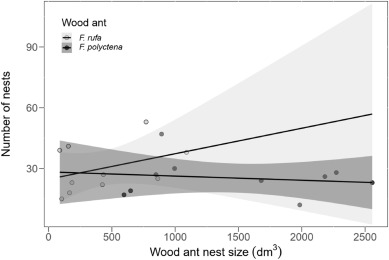

Fig. 2. The effect of the mound size of the wood ant species on the total number of the nests of the subordinate ant species registered in the plots within the territories of the two wood ant species *F. rufa* (light grey) and *F. polyctena* (dark grey). The black lines with confidence bands (grey) are plotted based on the linear regression of the two variables.

We found 50 (41.66%) plots with low wood ant presence (WA–) in *F. rufa* and 25 (20.83%) ones in *F. polyctena*, which resulted in 46 more nests of subordinate species within the territories of *F. rufa* (Table 1, S1). Based on the variables retained in the best models, the wood ant presence affected negatively the number of all nests and marginally the number of all *Myrmica* nests within the plots (Table 2). Such an effect could be observed on the number of *M. rubra* nests, but not in the *M. ruginodis*, or other species than those of the *Myrmica* genus (Table 2). In the latter, however, the wood ant presence had a negative effect only in the plots at 20 m (Table 2). Moreover, in the plots with higher wood ant presence (WA+), the number of nests was significantly higher in the plots at 30 m than at 20 m (Table 2). The distance from the mounds and wood ant activity did not have any other significant effects (Table 2). The wood ant species did not have a significant effect on the number of *M. ruginodis* nests (Table 2). Considering the total number of nests within plots, we did not find any relationship between plot distance and their direction (Chi2 = 7.07, p = 0.31).

Table 2. The effect of different variables on the number of nests (all nests, all *Myrmica* nests, nests belonging to species other than *Myrmica*, *M. rubra*, *M. ruginodis*) found around the mounds of the two wood ant species (*F. rufa* and *F. polyctena*). Only the variables retained in the best models are shown. Significant differences are indicated by bold *P* values.

| Model | Variable | *z* | *P* |
| --- | --- | --- | --- |
| No. of all nests | RWA– vs. RWA+ | **−2.24** | **0.025** |
| No. of all *Myrmica* nests | RWA– vs. RWA+ | **−1.93** | **0.054** |
| No. of all other than *Myrmica* nests | RWA–: 10 m vs. 20 m | 0.6 | 0.818 |
|  | RWA–: 10 m vs. 30 m | −0.98 | 0.593 |
|  | RWA–: 20 m vs. 30 m | −2.16 | 0.078 |
|  | RWA+: 10 m vs. 20 m | −2.08 | 0.094 |
|  | RWA+: 10 m vs. 30 m | 1.54 | 0.272 |
|  | RWA+: 20 m vs. 30 m | **2.71** | **0.018** |
|  | 10 m: RWA– vs. RWA+ | −0.97 | 0.332 |
|  | 20 m: RWA– vs. RWA+ | **−3.08** | **0.002** |
|  | 30 m: RWA– vs. RWA+ | 1.34 | 0.179 |
| No. of *M. rubra* nests | RWA– vs. RWA+ | **−2.64** | **0.008** |
| No. of *M. ruginodis* nests | FORU vs. FOPO | 1.18 | 0.238 |

The only variable included in the best model analysing the number of ant species within the different plots was the wood ant presence (WA-/WA+) that did not have a significant effect (GLMM z = −1.57, p = 0.12).

## 4. Discussion

We studied the small-scale effect of two territorial wood ant species on the occurrence of subordinate ants in the vicinity of their mounds. The smaller mound sizes found in *F. rufa* than those in *F. polyctena* were in concordance with a generally lower density of this species on its territory than that of the latter, however, this did not cause a difference in the nest number of other ant species within the compared wood ants’ territories. Intensity of the negative effect of wood ant activity on the nest density of the subordinate species within the studied plots was species-dependent. Moreover, the distribution of the nests of these species was only slightly influenced by the distance from the wood ant mounds even in plots with high wood ant presence.

The two wood ant species showed a clear difference in the mound size within the studied habitat, which might be linked to the monogynous or polygynous nature of the colonies of these species. Considering also these differences between the two species, like the common monogyny in *F. rufa* vs. high polygyny in *F. polyctena* (Czechowski et al., 2012; Seifert, 2018), their differential effect on nest density of the subordinate species would be expected. However, we did not find any significant difference regarding the diversity and abundance of other, mostly submissive ant species. Considering the smaller nest (= colony) sizes in *F. rufa*, this lack of differences can signal somehow a stronger effect of this species on other ants than that of *F. polyctena*. This may be associated with the diverse aggressiveness of workers of the territorial *Formica* species, decreasing in a gradient from monogynous-monodomous to polygynous-polydomous colonies (Pisarski 1973, 1982; Mabelis, 2003).

Considering strictly the nest density, it seems that in plots with higher ant activity, *F. rufa* workers had a lower effect on the number of nests of other ant species. These values (*F. rufa* WA+: 0.234/m<sup>2</sup>; *F. polyctena* WA+: 0.197/m<sup>2</sup>) were lower than those found in pine forest with high *F. polyctena* density (0.376/m<sup>2</sup>), but higher than the values for similar forest patches without wood ants (0.141/m<sup>2</sup>) in the Kampinos National Park, Central Poland (Gallé et al., 1998). The more northern patches of open pine forest (Tvärminne, S Finland) without herb layer or with a well-structured herb layer, both without wood ants, had similar nest densities (0.22/m<sup>2</sup> and 0.18/m<sup>2</sup>, respectively; Gallé et al. 2011) as in our case. Moreover, we found a much lower diversity than those found in the Kampinos National Park (2.19/m<sup>2</sup> without and 1.57/m<sup>2</sup> with *F. polyctena*) and in Tvärminne pine forests without wood ants (2.5/m<sup>2</sup>) (Gallé, 1991; Gallé et al., 1998). On the one hand, the low values found in our case can be due to the relatively close location of the study plots in relation to the wood ant mounds (10–30 m), which was not the case of the referred studies. Moreover, this is supported also by the findings of Czechowski et al. (1995) in the Białowieża Forest (in the other studied region of the forest than ours), where, in mature moist pine forests, practically without the wood ants, there were 15 ant species (with the most abundant in terms of the nest numbers *M. ruginodis* – 65% and *Leptothorax acervorum* – 16%) and a total nest density was 0.430/m<sup>2</sup>. However, in other mature moist pine forests, the same authors found nest densities similar to ours (Biała Forest: 13 species, 0.286/m<sup>2</sup>; Tucholskie Forests: 8 species, 0.224/m<sup>2</sup>; Czechowski et al., 1995).

Another possible explanation for the lower ant species richness found in the older stands dominated by wood ants (what results from their life history; see Pisarski and Czechowski, 1994) can be related to habitat characteristics, like the herb layer, soil type or other conditions in these stands that allow the adaptation for only a few ant species, and in such situations, even the removal of the dominant wood ants can have no effect on other species (Gibb and Johansson, 2010; Johansson and Gibb, 2016). On the other hand, the relatively high ant abundance values found in the older tree stands in the presence of wood ants (both in our study and in the Kampinos National Park; Gallé et al., 1998), might be due to the indirect positive effects of wood ants on some of the ant species, like the shelter offered for some submissives (Savolainen and Vepsäläinen, 1989; Czechowski and Vepsäläinen, 2001; Czechowski and Markó, 2006; Väänänen et al., 2010; Stukalyuk, 2015). In addition, other ant species nesting within wood ants’ territories may also use small food items left behind by wood ant foragers or honeydew falling on the ground during its exploitation (Dixon, 2005; Seeger and Filser, 2008). Such waste can be important food sources in relatively poor habitats.

We found a negative effect of the wood ant activity on the distribution of some subordinate ant species, mostly *M. rubra.* However, no such effect was detected on the *M. ruginodis* and encounter species (i.e. those of the genera *Lasius* and *Camponotus*), which had a quite even distribution along the growing distance from the wood ant mounds. This is contrary to the clear negative effects of *F. polyctena* found in Finland (Savolainen and Vepsäläinen, 1989). This difference can be caused by various factors. On the one hand, the availability of the wood ants’ food sources is much higher in the southern than northern regions, which mostly concerns the main source, namely honeydew (Johansson and Gibb, 2016). Generally, a seasonality is found in the food demand of wood ant colonies, with a food shortage leading to higher competition and strong territoriality in the spring and lower demand in the mid-summer period (June–July) after flying out (nuptial flights usually occur in May to June; Czechowski et al., 2012; Seifert, 2018) of the sexuals (Hölldobler and Lumsden, 1980). In the latter period, wood ants defend only specific resources (aphid colonies) within their home range (Hölldobler and Lumsden, 1980). This can lead to lower pressure on other ant species living in the neighbourhood of wood ant mounds in this period (Johansson and Gibb, 2016). However, this can change in the late summer and autumn, when the high protein demand of the brood can lead to an increase in prey retrieval (Rosengren, 1977). On the other hand, the most abundant ant species within the wood ant territories were two species of the genus *Myrmica*. They differ from wood ants in many respects: morphologically, behaviourally, they have different foraging strategy, periods of activity, a way of the area splitting, etc. (Savolainen and Vepsäläinen, 1989). Their workers can escape conflicts close to a wood ant mound by shifting from surface activity to the litter (Savolainen and Vepsäläinen, 1988, Savolainen and Vepsäläinen, 1989; Savolainen, 1990), but they are also capable to survive in small patches with small colonies that they can move easily if disturbed (Savolainen and Vepsäläinen, 1989; Vepsäläinen and Savolainen, 1990; Banschbach and Herbers, 1999). In addition, though these two species, *M. rubra* and *M. ruginodis*, differ morphologically and also their ecological requirements overlap (Mabelis, 1977; Alvarado and Gallé, 2000; Vepsäläinen et al., 2000; Czechowski et al., 2012). Although the negative relationship and nest displacement between these two *Myrmica* species can be high (Mabelis, 1977; Elmes, 1991; Markó et al., 2004), we found them next to each other in several plots. The more pronounced negative impact of wood ant activity on *M. rubra,* which has usually larger colonies (Elmes, 1991), is in concordance with the more aggressive nature of this species. On the other hand, *M. ruginodis* shows two social forms: the polygynous microgyna form, which is specialized in changing habitats, and the monogynous macrogyna form, which is specialized in stable climax habitats that can be dominated by wood ants (Seppä and Walin, 1996). This second form is able to coexist with wood ants (Seppä and Walin, 1996), which seems to be the situation of our findings.

Similarly to *M. ruginodis*, the wood ant activity did not have a significant effect on the distribution of the other subordinate species (both encounterers and submissives), although the number of their nests was generally quite low. However, there were more plots with low wood ant presence in *F. rufa* than in *F. polyctena*, and this did not lead to any significant difference in the number of subordinate species, their nest densities and diversity (except *Myrmica* spp.) found in plots with low wood ant presence. Submissive species may display special adaptations to life in the territories of dominant species which help them to survive in the neighbourhood of their colonies (Savolainen and Vepsäläinen, 1988; Vepsäläinen and Savolainen, 1990; Savolainen, 1991; Czechowski and Vepsäläinen, 1999; Erős et al., 2020). Encounter species, in turn, usually establish their colonies close to the territory borders, as far as possible from the nests of dominants, where foraging activity of the latter is relatively low (Savolainen and Vepsäläinen, 1989, Savolainen and Vepsäläinen, 1988; Savolainen and Vepsäläinen, 1988, Savolainen and Vepsäläinen, 1989; Savolainen, 1990; Markó and Czechowski, 2004, 2012; Johansson and Gibb, 2016). Moreover, as with submissives, alternative foraging strategies of these species also increase their chances of successful coexisting with the dominant wood ants (Johansson and Gibb, 2016). For example, *Camponotus* species usually forage individually, without special attention from a stronger competitor. In turn, encounter *Lasius* species tend to forage underground, attending root aphids or building protective earth shelters around aphids on plant stems (Czechowski et al., 2011; Johansson and Gibb, 2016; Seifert, 2018). All these adaptations allow the occurrence of various subordinate species, even with reduced colony size and low reproduction rate within territories of the top dominants of the interspecific competition ant hierarchy (Rosengren, 1986; Savolainen and Vepsäläinen, 1988, Savolainen and Vepsäläinen, 1989; Pisarski and Vepsäläinen 1989; Savolainen et al., 1989; Savolainen, 1990, 1991; Vepsäläinen and Savolainen, 1990; Gallé et al., 1998; Czechowski and Vepsäläinen, 1999; Trigos-Peral et al., 2020).

## Author contributions

I.M., I.S. and W.Cz. conceived and designed the study; I.M., I.S., O.J., A.T. and J.C. performed field surveys and collected the data; G.T.P. identified the ants; I.M. and O.J. analysed the data; I.M., G.T.P., W.Cz. prepared the figures, and wrote the manuscript. All the authors reviewed and approved the manuscript.

## Data availability

The datasets generated and/or analysed during the current study are available from the corresponding author on reasonable request.

## Declaration of competing interest

The authors declare that they have no known competing financial interests or personal relationships that could have appeared to influence the work reported in this paper.

## Acknowledgements

This research was supported by the Gwiazda grant of the Museum and Institute of Zoology, Polish Academy of Sciences and a project (no. 240609) of the Polish Forest Research Institute, supported by the Polish Ministry of Science and Higher Education (2016–2018). The authors thank the Polish Forest Research Institute (IBL), for permission to carry out the fieldwork on the area under its scientific care and hosting during the time of the research.

## Appendix A. Supplementary data

The following is the Supplementary data to this article:[Download : Download Word document (15KB)](https://ars.els-cdn.com/content/image/1-s2.0-S1146609X21000084-mmc1.docx)

Multimedia component 1.

## References

**Adams, 2016**

E.S. Adams

**Territoriality in ants (Hymenoptera: Formicidae): a review**

Myrmecol. News, 23 (2016), pp. 101-118

[View Record in Scopus](https://www.scopus.com/inward/record.url?eid=2-s2.0-85002027463&partnerID=10&rel=R3.0.0)[Google Scholar](https://scholar.google.com/scholar?q=Territoriality%20in%20ants%20:%20a%20review)

**Adler et al., 2007**

F.R. Adler, E.G. Lebrun, D.H. Feener Jr.

**Maintaining diversity in an ant community: modeling, extending, and testing the dominance discovery trade off**

Am. Nat., 169 (2007), pp. 323-333, 10.1086/510759

[View Record in Scopus](https://www.scopus.com/inward/record.url?eid=2-s2.0-33847406241&partnerID=10&rel=R3.0.0)Google Scholar

**Alvarado and Gallé, 2000**

M. Alvarado, L. Gallé

**Ant assemblages associated with lowland forests in the southern part of the Great Hungarian Plain**

Acta Zool. Hung., 46 (2000), pp. 79-102

[View Record in Scopus](https://www.scopus.com/inward/record.url?eid=2-s2.0-0039172845&partnerID=10&rel=R3.0.0)Google Scholar

**Bansbach and Herbers, 1999**

V.S. Bansbach, J.M. Herbers

**Nest movements and population spatial structure of the forest ant *Myrmica punctiventris* (Hymenoptera: Formicidae)**

Ann. Entomol. Soc. Am., 92 (1999), pp. 414-423

[Google Scholar](https://scholar.google.com/scholar?q=Nest%20movements%20and%20population%20spatial%20structure%20of%20the%20forest%20ant%20Myrmica%20punctiventris)

**Bartoń, 2019**

K. Bartoń

**MuMIn: Multi-Model Inference**

(2019)

R package version 1.43.6

[http://CRAN.R-project.org/package=MuMIn](http://cran.r-project.org/package=MuMIn), Accessed 29th Oct 2013

published online

[Google Scholar](https://scholar.google.com/scholar_lookup?title=MuMIn%3A%20Multi-Model%20Inference&publication_year=2019&author=K.%20Barto%C5%84)

**Bates et al., 2013**

D. Bates, M. Maechler, B. Bolker, S. Walker

**lme4: Linear Mixed-Effects Models Using Eigen and S4. R Package Version 1.0-5**

(2013)

[http://CRAN.R-project.org/package=lme4](http://cran.r-project.org/package=lme4), Accessed 25th Oct 2013

published online

Google Scholar

**Braschler and Baur, 2003**

B. Braschler, B. Baur

**Effects of experimental small‐scale grassland fragmentation on spatial distribution, density, and persistence of ant nests**

Ecol. Entomol., 28 (2003), pp. 651-658, 10.1111/j.1365-2311.2003.00549.x

[View Record in Scopus](https://www.scopus.com/inward/record.url?eid=2-s2.0-0347567114&partnerID=10&rel=R3.0.0)[Google Scholar](https://scholar.google.com/scholar?q=Effects%20of%20experimental%20smallscale%20grassland%20fragmentation%20on%20spatial%20distribution,%20density,%20and%20persistence%20of%20ant%20nests)

**Cerda et al., 2013**

X. Cerda, X. Arnan, J. Retana

**Is competition a significant hallmark of ant (Hymenoptera: Formicidae) ecology**

Myrmecol. News, 18 (2013), pp. 131-147

[View Record in Scopus](https://www.scopus.com/inward/record.url?eid=2-s2.0-84875521073&partnerID=10&rel=R3.0.0)[Google Scholar](https://scholar.google.com/scholar?q=Is%20competition%20a%20significant%20hallmark%20of%20ant%20%20ecology)

**Collingwood, 1979**

C.A. Collingwood

**The Formicidae (Hymenoptera) of Fennoscandia and Denmark**

Fauna Entomol. Scand., 8 (1979), pp. 1-174

[Google Scholar](https://scholar.google.com/scholar?q=The%20Formicidae%20%20of%20Fennoscandia%20and%20Denmark)

**Czechowski, 1976**

W. Czechowski

**Ants cemeteries**

Przeglad Zool., 20 (1976), pp. 417-427

[in Polish with English summary]

[Google Scholar](https://scholar.google.com/scholar_lookup?title=Ants%20cemeteries&publication_year=1976&author=W.%20Czechowski)

**Czechowski, 2008**

W. Czechowski

**Around nest cemeteries of *Myrmica schencki* Em. (Hymenoptera: Formicidae): their origin and a possible significance**

Pol. J. Ecol., 56 (2008), pp. 359-363

[View Record in Scopus](https://www.scopus.com/inward/record.url?eid=2-s2.0-48249083447&partnerID=10&rel=R3.0.0)[Google Scholar](https://scholar.google.com/scholar?q=Around%20nest%20cemeteries%20of%20Myrmica%20schencki%20Em.%20:%20their%20origin%20and%20a%20possible%20significance)

**Czechowski and Vepsӓlӓinen, 1999**

W. Czechowski, K. Vepsӓlӓinen

**Plesiobiosis between *Formica fusca* L. And *Formica aquilonia* Yarr. (Hymenoptera, Formicidae)**

Ann. Zool., 49 (1999), pp. 125-127

[View Record in Scopus](https://www.scopus.com/inward/record.url?eid=2-s2.0-0012367992&partnerID=10&rel=R3.0.0)[Google Scholar](https://scholar.google.com/scholar?q=Plesiobiosis%20between%20Formica%20fusca%20L.%20And%20Formica%20aquilonia%20Yarr.)

**Czechowski and Vepsalainen, 2001**

W. Czechowski, K. Vepsalainen

*Formica rufa* protects indirectly *F. fusca* against raids of *F. sanguinea*

Ann. Zool., 51 (2001), pp. 267-273

[View Record in Scopus](https://www.scopus.com/inward/record.url?eid=2-s2.0-0011971255&partnerID=10&rel=R3.0.0)[Google Scholar](https://scholar.google.com/scholar_lookup?title=Formica%20rufa%20protects%20indirectly%20F.%20fusca%20against%20raids%20of%20F.%20sanguinea&publication_year=2001&author=W.%20Czechowski&author=K.%20Vepsalainen)

**Czechowski and Markó, 2005**

W. Czechowski, B. Markó

**Competition between *Formica cinerea* Mayr (Hymenoptera: Formicidae) and co-occurring ant species, with special reference to *Formica rufa* L.: direct and indirect interferences**

Pol. J. Ecol., 53 (2005), pp. 467-487

[View Record in Scopus](https://www.scopus.com/inward/record.url?eid=2-s2.0-31544455010&partnerID=10&rel=R3.0.0)Google Scholar

**Czechowski and Markó, 2006**

W. Czechowski, B. Markó

**Uncomfortable protection: *Formica polyctena* Först. Shelters *Formica fusca* L. From *Formica sanguinea* Latr. (Hymenoptrea: Formicidae)**

Ann. Zool., 56 (2006), pp. 539-548, 10.3161/000345406778811808

[View Record in Scopus](https://www.scopus.com/inward/record.url?eid=2-s2.0-33750709691&partnerID=10&rel=R3.0.0)[Google Scholar](https://scholar.google.com/scholar?q=Uncomfortable%20protection:%20Formica%20polyctena%20F%C3%B6rst.%20Shelters%20Formica%20fusca%20L.%20From%20Formica%20sanguinea%20Latr.)

**Czechowski and Vepsӓlӓinen, 2009**

W. Czechowski, K. Vepsӓlӓinen

**Territory size of wood ants (Hymenoptera: Formicidae): a search for limits of existence of *Formica polyctena* Först., an inherently polygynic and polycalic species**

Ann. Zool., 59 (2009), pp. 179-187, 10.3161/000345409X463994

[View Record in Scopus](https://www.scopus.com/inward/record.url?eid=2-s2.0-67651165385&partnerID=10&rel=R3.0.0)Google Scholar

**Czechowski et al., 1995**

W. Czechowski, B. Pisarski, K. Yamauchi

**Succession of ant communities (Hymenoptera, Formicidae) in moist pine forests**

Fragm. Faun. (Wars.), 38 (1995), pp. 447-488

[CrossRef](https://doi.org/10.3161/00159301FF1995.38.24.447)[Google Scholar](https://scholar.google.com/scholar?q=Succession%20of%20ant%20communities%20%20in%20moist%20pine%20forests)

**Czechowski et al., 2011**

W. Czechowski, B. Markó, K. Erős, E. Csata

**Pollenivory in ants (Hymenoptera: Formicidae) seems to be much more common than it was thought**

Ann. Zool., 61 (2011), pp. 519-525

[View Record in Scopus](https://www.scopus.com/inward/record.url?eid=2-s2.0-80053976380&partnerID=10&rel=R3.0.0)[Google Scholar](https://scholar.google.com/scholar?q=Pollenivory%20in%20ants%20%20seems%20to%20be%20much%20more%20common%20than%20it%20was%20thought)

**Czechowski et al., 2012**

W. Czechowski, A. Radchenko, W. Czechowska, K. Vepsäläinen

**The Ants of Poland with Reference to the Myrmecofauna of Europe**

Fauna Poloniae 4

Natura Optima Dux Foundation, Warszawa, Poland (2012), pp. 189-205

Google Scholar

**Czechowski et al., 2013**

W. Czechowski, B. Markó, A. Radchenko, P. Ślipiński

**Long-term partitioning of space between two territorial species of ants (Hymenoptera: Formicidae) and their effect on subordinate species**

Eur. J. Entomol., 110 (2013), pp. 327-337

[CrossRef](https://doi.org/10.14411/eje.2013.046)[View Record in Scopus](https://www.scopus.com/inward/record.url?eid=2-s2.0-84875861550&partnerID=10&rel=R3.0.0)[Google Scholar](https://scholar.google.com/scholar?q=Long-term%20partitioning%20of%20space%20between%20two%20territorial%20species%20of%20ants%20%20and%20their%20effect%20on%20subordinate%20species)

**Davidson, 1977**

D. Davidson

**Species diversity and community organization in desert seed-eating ants**

Ecology, 58 (1977), pp. 711-724, 10.2307/1936208

[CrossRef](https://doi.org/10.2307/1936208)[Google Scholar](https://scholar.google.com/scholar_lookup?title=Species%20diversity%20and%20community%20organization%20in%20desert%20seed-eating%20ants&publication_year=1977&author=D.%20Davidson)

**Dixon, 2005**

T. Dixon

**Insect Herbivore – Host Dynamics**

*Tree-dwelling aphids*. Cambridge University Press, Cambridge (2005)

[Google Scholar](https://scholar.google.com/scholar?q=Insect%20Herbivore%20%20Host%20Dynamics)

**Dlusskij, 1967**

G.M. Dlusskij

**Ants of the genus *Formica* (Hymenoptera, Formicidae, g. *Formica*)**

Nauka, Moskva (1967), p. 236

[in Russian]

[Google Scholar](https://scholar.google.com/scholar?q=Ants%20of%20the%20genus%20Formica)

**Elmes, 1991**

G.W. Elmes

**The social biology of *Myrmica* ants**

Actes Coll. Insect. Soc., 7 (1991), pp. 17-34

[View Record in Scopus](https://www.scopus.com/inward/record.url?eid=2-s2.0-0002787589&partnerID=10&rel=R3.0.0)[Google Scholar](https://scholar.google.com/scholar_lookup?title=The%20social%20biology%20of%20Myrmica%20ants&publication_year=1991&author=G.W.%20Elmes)

**Erős et al., 2020**

K. Erős, I. Maák, B. Markó, H. Babik, P. Ślipiński, R. Nicoară, W. Czechowski

**Competitive pressure by territorials promotes utilization of unusual food source by subordinate ants in temperate European woodlands**

Ethol. Ecol. Evol., 32 (2020), pp. 457-465, 10.1080/03949370.2020.1753116

[CrossRef](https://doi.org/10.1080/03949370.2020.1753116)[View Record in Scopus](https://www.scopus.com/inward/record.url?eid=2-s2.0-85084433553&partnerID=10&rel=R3.0.0)Google Scholar

**Forest Data Bank,**

Forest Data Bank

**Bank Danych o Lasach**

https://www.bdl.lasy.gov.pl/portal/mapy-en

(Accessed 28 June 2020)

[Google Scholar](https://scholar.google.com/scholar?q=Bank%20Danych%20o%20Lasach)

**Gallé, 1991**

L. Gallé

**Structure and succession of ant assemblages in a north European sand dune area**

Holarctic Ecol., 14 (1991), pp. 31-37

[CrossRef](https://doi.org/10.1111/j.1600-0587.1991.tb00630.x)[View Record in Scopus](https://www.scopus.com/inward/record.url?eid=2-s2.0-0025956029&partnerID=10&rel=R3.0.0)[Google Scholar](https://scholar.google.com/scholar_lookup?title=Structure%20and%20succession%20of%20ant%20assemblages%20in%20a%20north%20European%20sand%20dune%20area&publication_year=1991&author=L.%20Gall%C3%A9)

**Gallé et al., 1998**

L. Gallé, L. Körmöczi, E. Hornung, J. Kerekes

**Structure of ant-assemblages in a middle-european successional sand-dune area**

Tiscia, 31 (1998), pp. 19-28

[View Record in Scopus](https://www.scopus.com/inward/record.url?eid=2-s2.0-0040635819&partnerID=10&rel=R3.0.0)Google Scholar

**Gibb, 2011**

H. Gibb

**Experimental evidence for mediation of competition by habitat succession**

Ecology, 92 (2011), p. 1871, 10.1890/10-2363.1

[CrossRef](https://doi.org/10.1890/10-2363.1)[View Record in Scopus](https://www.scopus.com/inward/record.url?eid=2-s2.0-80053594230&partnerID=10&rel=R3.0.0)[Google Scholar](https://scholar.google.com/scholar_lookup?title=Experimental%20evidence%20for%20mediation%20of%20competition%20by%20habitat%20succession&publication_year=2011&author=H.%20Gibb)

**Gibb and Johansson, 2010**

H. Gibb, T. Johansson

**Forest succession and harvesting of hemipteran honeydew by boreal ants**

Ann. Zool. Fenn., 47 (2010), pp. 99-110

[CrossRef](https://doi.org/10.5735/086.047.0203)[View Record in Scopus](https://www.scopus.com/inward/record.url?eid=2-s2.0-77952725670&partnerID=10&rel=R3.0.0)[Google Scholar](https://scholar.google.com/scholar_lookup?title=Forest%20succession%20and%20harvesting%20of%20hemipteran%20honeydew%20by%20boreal%20ants&publication_year=2010&author=H.%20Gibb&author=T.%20Johansson)

**Glen and Dickman, 2008**

A.S. Glen, C.R. Dickman

**Niche overlap between marsupial and eutherian carnivores: does competition threaten the endangered spotted-tailed quoll?**

J. Appl. Ecol., 45 (2008), pp. 700-707, 10.1111/j.1365-2664.2007.01449.x

[CrossRef](https://doi.org/10.1111/j.1365-2664.2007.01449.x)[View Record in Scopus](https://www.scopus.com/inward/record.url?eid=2-s2.0-40949113725&partnerID=10&rel=R3.0.0)[Google Scholar](https://scholar.google.com/scholar?q=Niche%20overlap%20between%20marsupial%20and%20eutherian%20carnivores:%20does%20competition%20threaten%20the%20endangered%20spotted-tailed%20quoll)

**Gordon, 2010**

D.M. Gordon

**Ant Encounters: Interaction Networks and Colony Behavior**

Princeton University Press, USA (2010)

[Google Scholar](https://scholar.google.com/scholar_lookup?title=Ant%20Encounters%3A%20Interaction%20Networks%20and%20Colony%20Behavior&publication_year=2010&author=D.M.%20Gordon)

**Hölldobler and Wilson, 1977**

B. Hölldobler, E.O. Wilson

**The number of queens: an important trait in ant evolution**

Naturwissenschaften, 64 (1977), pp. 8-15, 10.1007/BF00439886

[View Record in Scopus](https://www.scopus.com/inward/record.url?eid=2-s2.0-0002543329&partnerID=10&rel=R3.0.0)[Google Scholar](https://scholar.google.com/scholar_lookup?title=The%20number%20of%20queens%3A%20an%20important%20trait%20in%20ant%20evolution&publication_year=1977&author=B.%20H%C3%B6lldobler&author=E.O.%20Wilson)

**Hölldobler and Lumsden, 1980**

B. Hölldobler, C.J. Lumsden

**Territorial strategies in ants**

Science, 210 (1980), pp. 732-739

[View Record in Scopus](https://www.scopus.com/inward/record.url?eid=2-s2.0-0019173853&partnerID=10&rel=R3.0.0)[Google Scholar](https://scholar.google.com/scholar_lookup?title=Territorial%20strategies%20in%20ants&publication_year=1980&author=B.%20H%C3%B6lldobler&author=C.J.%20Lumsden)

**Hölldobler and Wilson, 1990**

B. Hölldobler, E.O. Wilson

**The Ants**

The Belknap Press of Harvard University Press, Cambridge, USA (1990)

[Google Scholar](https://scholar.google.com/scholar_lookup?title=The%20Ants&publication_year=1990&author=B.%20H%C3%B6lldobler&author=E.O.%20Wilson)

**Howard and Tschinkel, 1976**

D. Howard, W.R. Tschinkel

**Aspects of necrophoric behavior in the red imported fire ant, *Solenopsis invicta***

Behavior (56) (1976), pp. 157-178

[CrossRef](https://doi.org/10.1163/156853976X00334)Google Scholar

**Johansson and Gibb, 2016**

T. Johansson, H. Gibb

**Interspecific competition and coexistence between wood ants**

J.A. Stockan, E.J. Robinson (Eds.), Wood Ant Ecology and Conservation, Cambridge University Press, Cambridge, UK (2016)

13: 9781107048331

[Google Scholar](https://scholar.google.com/scholar_lookup?title=Interspecific%20competition%20and%20coexistence%20between%20wood%20ants&publication_year=2016&author=T.%20Johansson&author=H.%20Gibb)

**Levings and Traniello, 1981**

S. Levings, J. Traniello

**Territoriality, nest dispersion, and community structure in ants**

Psyche, 88 (1981), pp. 265-319, 10.1155/1981/20795

[CrossRef](https://doi.org/10.1155/1981/20795)[View Record in Scopus](https://www.scopus.com/inward/record.url?eid=2-s2.0-0000334201&partnerID=10&rel=R3.0.0)[Google Scholar](https://scholar.google.com/scholar_lookup?title=Territoriality%2C%20nest%20dispersion%2C%20and%20community%20structure%20in%20ants&publication_year=1981&author=S.%20Levings&author=J.%20Traniello)

**Lindén and Mäntyniemi, 2011**

A. Lindén, S. Mäntyniemi

**Using the negative binomial distribution to model overdispersion in ecological count data**

Ecology, 97 (2011), pp. 1414-1421

[CrossRef](https://doi.org/10.1890/10-1831.1)[View Record in Scopus](https://www.scopus.com/inward/record.url?eid=2-s2.0-79960459057&partnerID=10&rel=R3.0.0)Google Scholar

**Maák et al., 2020**

I. Maák, Zs Czekes, K. Erős, Zs Pálfi, B. Markó

**Living on the edge: changes in the foraging strategy of a territorial ant species occurring with a rival supercolony – a case study**

J. Insect Behav., 33 (2020), pp. 59-68

[CrossRef](https://doi.org/10.1007/s10905-020-09745-x)[View Record in Scopus](https://www.scopus.com/inward/record.url?eid=2-s2.0-85086341475&partnerID=10&rel=R3.0.0)Google Scholar

**Mabelis, 1977**

A.A. Mabelis

**Artenreichtum von Ameisen in einigen Waldtypen**

R. Tüxen (Ed.), Berichte der Internationalen Symposien der Internationalen Vereinigung für Vegetationskunde, Vaduz (1977)

[Google Scholar](https://scholar.google.com/scholar_lookup?title=Artenreichtum%20von%20Ameisen%20in%20einigen%20Waldtypen&publication_year=1977&author=A.A.%20Mabelis)

**Mabelis, 2003**

A.A. Mabelis

**Do *Formica* species (Hymenoptera: Formicidae) have a different attack mode?**

Ann. Zool., 53 (2003), pp. 667-668

[View Record in Scopus](https://www.scopus.com/inward/record.url?eid=2-s2.0-1042267807&partnerID=10&rel=R3.0.0)[Google Scholar](https://scholar.google.com/scholar?q=Do%20Formica%20species%20%20have%20a%20different%20attack%20mode)

**Marikovsky, 1963**

P.I. Marikovsky

**The ants *Formica sanguinea* as pillagers of *Formica rufa* Lin. nests**

Insect. Soc., 10 (1963), pp. 119-128

[View Record in Scopus](https://www.scopus.com/inward/record.url?eid=2-s2.0-0038163380&partnerID=10&rel=R3.0.0)[Google Scholar](https://scholar.google.com/scholar_lookup?title=The%20ants%20Formica%20sanguinea%20as%20pillagers%20of%20Formica%20rufa%20Lin.%20nests&publication_year=1963&author=P.I.%20Marikovsky)

**Markó and Czechowski, 2004**

B. Markó, W. Czechowski

*Lasius psammophilus* Seifert and *Formica cinerea* Mayr (Hymenoptera: Formicidae) on sand dunes: conflict and coexistence

Ann. Zool., 54 (2004), pp. 365-378, 10.3161/0003454043540909

[View Record in Scopus](https://www.scopus.com/inward/record.url?eid=2-s2.0-3142657616&partnerID=10&rel=R3.0.0)[Google Scholar](https://scholar.google.com/scholar?q=Lasius%20psammophilus%20Seifert%20and%20Formica%20cinerea%20Mayr%20%20on%20sand%20dunes:%20conflict%20and%20coexistence)

**Markó and Czechowski, 2012**

B. Markó, W. Czechowski

**Space use, foraging success and competitive relationships in *Formica cinerea* (Hymenoptera Formicidae) on sand dunes in southern Finland**

Ethol. Ecol. Evol., 24 (2012), pp. 149-164

[CrossRef](https://doi.org/10.1080/03949370.2011.634438)[View Record in Scopus](https://www.scopus.com/inward/record.url?eid=2-s2.0-84859124803&partnerID=10&rel=R3.0.0)[Google Scholar](https://scholar.google.com/scholar?q=Space%20use,%20foraging%20success%20and%20competitive%20relationships%20in%20Formica%20cinerea%20%20on%20sand%20dunes%20in%20southern%20Finland)

**Markó et al., 2004**

B. Markó, K. Kiss, L. Gallé

**Mosaic structure of ant communities (Hymenoptera: Formicidae) in eastern Carpathian marshes: regional versus local scales**

Acta Zool. Hung., 50 (2004), pp. 77-95

[View Record in Scopus](https://www.scopus.com/inward/record.url?eid=2-s2.0-41949106611&partnerID=10&rel=R3.0.0)[Google Scholar](https://scholar.google.com/scholar?q=Mosaic%20structure%20of%20ant%20communities%20%20in%20eastern%20Carpathian%20marshes:%20regional%20versus%20local%20scales)

**Markó et al., 2013**

B. Markó, W. Czechowski, A. Radchenko

**Combining competition with predation: drastic effect of *Lasius fuliginosus* (Latr.) on subordinate ant species at the northern limit of its distribution**

Ann. Zool., 63 (2013), pp. 107-111, 10.3161/000345413X666156

[CrossRef](https://doi.org/10.3161/000345413X666156)[View Record in Scopus](https://www.scopus.com/inward/record.url?eid=2-s2.0-84875856194&partnerID=10&rel=R3.0.0)Google Scholar

**Mori et al., 2000**

A. Mori, D. Grasso, F. Le Moli

**Raiding and foraging behavior of the blood-red ant, *Formica sanguinea* Latr. (Hymenoptera, Formicidae)**

J. Insect Behav., 13 (2000), pp. 421-437

[View Record in Scopus](https://www.scopus.com/inward/record.url?eid=2-s2.0-0033868441&partnerID=10&rel=R3.0.0)[Google Scholar](https://scholar.google.com/scholar?q=Raiding%20and%20foraging%20behavior%20of%20the%20blood-red%20ant,%20Formica%20sanguinea%20Latr.)

**Pianka, 1974**

E.R. Pianka

**Niche overlap and diffuse competition**

Proc. Natl. Acad. Sci. Unit. States Am., 71 (1974), pp. 2141-2145, 10.1073/pnas.71.5.2141

[CrossRef](https://doi.org/10.1073/pnas.71.5.2141)[View Record in Scopus](https://www.scopus.com/inward/record.url?eid=2-s2.0-0005673720&partnerID=10&rel=R3.0.0)[Google Scholar](https://scholar.google.com/scholar_lookup?title=Niche%20overlap%20and%20diffuse%20competition&publication_year=1974&author=E.R.%20Pianka)

**Pierzgalski et al., 2002**

E. Pierzgalski, A. Boczoń, J. Tyszka

**Variability of precipitation and ground water level in the Białowieża National Park**

Kosmos, 51 (2002), pp. 415-425

[View Record in Scopus](https://www.scopus.com/inward/record.url?eid=2-s2.0-34347215214&partnerID=10&rel=R3.0.0)Google Scholar

**Pisarski, 1973**

B. Pisarski

**Social structure of *Formica* (*Coptoformica*) *exsecta* Nyl. (Hymenoptera: Formicidae) and its influence on morphology, ecology and ethology of the species**

Zoological Institute PAS, Warszawa (1973), p. 134

[in Polish]

[Google Scholar](https://scholar.google.com/scholar?q=Social%20structure%20of%20Formica%20%20exsecta%20Nyl.%20%20and%20its%20influence%20on%20morphology,%20ecology%20and%20ethology%20of%20the%20species)

**Pisarski, 1982**

**Structure et organisation des societies de fourmis de l’espèce *Formica* (*Coptoformica) exsecta* Nyl. (Hymenoptera, Formicidae)**

B. Pisarski (Ed.), Memorabilia Zool., 38 (1982), p. 281

[Google Scholar](https://scholar.google.com/scholar?q=Structure%20et%20organisation%20des%20societies%20de%20fourmis%20de%20lesp%C3%A8ce%20Formica%20%20exsecta%20Nyl.)

**Pisarski and Vepsäläinen, 1989**

B. Pisarski, K. Vepsäläinen

**Competition hierarchies in ant communities (Hymenoptera, Formicidae)**

Ann. Zool., 42 (1989), pp. 321-329

[View Record in Scopus](https://www.scopus.com/inward/record.url?eid=2-s2.0-0001462424&partnerID=10&rel=R3.0.0)[Google Scholar](https://scholar.google.com/scholar?q=Competition%20hierarchies%20in%20ant%20communities)

**Pisarski and Czechowski, 1994**

B. Pisarski, W. Czechowski

**Ways to reproductive success of wood ant queens**

Memorabilia Zool., 48 (1994), pp. 181-186

[View Record in Scopus](https://www.scopus.com/inward/record.url?eid=2-s2.0-0038857684&partnerID=10&rel=R3.0.0)[Google Scholar](https://scholar.google.com/scholar_lookup?title=Ways%20to%20reproductive%20success%20of%20wood%20ant%20queens&publication_year=1994&author=B.%20Pisarski&author=W.%20Czechowski)

**Punttila et al., 1996**

P. Punttila, Y. Haila, H. Tukia

**Ant communities in taiga clearcuts: habitat effects and species interactions**

Ecography, 19 (1996), pp. 16-28, 10.1111/j.1600-0587.1996.tb00151.x

[CrossRef](https://doi.org/10.1111/j.1600-0587.1996.tb00151.x)[View Record in Scopus](https://www.scopus.com/inward/record.url?eid=2-s2.0-0030304968&partnerID=10&rel=R3.0.0)Google Scholar

**Punttila and Kilpeläinen, 2009**

P. Punttila, J. Kilpeläinen

**Distribution of mound-building ant species (*Formica* spp., Hymenoptera) in Finland: preliminary results of a national survey**

Ann. Zool. Fenn., 46 (2009), pp. 1-15

[CrossRef](https://doi.org/10.5735/086.046.0101)[View Record in Scopus](https://www.scopus.com/inward/record.url?eid=2-s2.0-63449083477&partnerID=10&rel=R3.0.0)[Google Scholar](https://scholar.google.com/scholar?q=Distribution%20of%20mound-building%20ant%20species%20%20in%20Finland:%20preliminary%20results%20of%20a%20national%20survey)

**R Core Team, 2019**

R Core Team

**R: A language and environment for statistical computing**

R Foundation for Statistical Computing, Vienna, Austria (2019)

Retrieved from

[http://www.R-project.org/](http://www.r-project.org/)

[Google Scholar](https://scholar.google.com/scholar_lookup?title=R%3A%20A%20language%20and%20environment%20for%20statistical%20computing&publication_year=2019&author=R%20Core%20Team)

**Reznikova, 1982**

J.I. Reznikova

**Interspecific communication between ants**

Behaviour, 80 (1982), pp. 84-95, 10.1163/156853982X00454

[View Record in Scopus](https://www.scopus.com/inward/record.url?eid=2-s2.0-0020220097&partnerID=10&rel=R3.0.0)[Google Scholar](https://scholar.google.com/scholar_lookup?title=Interspecific%20communication%20between%20ants&publication_year=1982&author=J.I.%20Reznikova)

**Risch et al., 2005**

A.C. Risch, M.F. Jurgensen, M. Schütz, D.S. Page-Dumroese

**The contribution of red wood ants to soil C and N pools and CO2 emissions in subalpine forests**

Ecology, 86 (2005), pp. 419-430

[CrossRef](https://doi.org/10.1890/04-0159)[View Record in Scopus](https://www.scopus.com/inward/record.url?eid=2-s2.0-14844365354&partnerID=10&rel=R3.0.0)Google Scholar

**Rosengren, 1977**

R. Rosengren

**Foraging strategy of wood ants (*Formica rufa* group). I. Age polyethism and topographic traditions**

Ann. Zool. Fenn., 150 (1977), pp. 1-30

[View Record in Scopus](https://www.scopus.com/inward/record.url?eid=2-s2.0-0002569592&partnerID=10&rel=R3.0.0)[Google Scholar](https://scholar.google.com/scholar?q=Foraging%20strategy%20of%20wood%20ants%20.%20I.%20Age%20polyethism%20and%20topographic%20traditions)

**Rosengren, 1986**

R. Rosengren

**Competition and coexistence in an insular ant community: a manipulation experiment (Hymenoptera: Formicidae)**

Ann. Zool. Fenn., 23 (1986), pp. 297-302

[View Record in Scopus](https://www.scopus.com/inward/record.url?eid=2-s2.0-0022830775&partnerID=10&rel=R3.0.0)[Google Scholar](https://scholar.google.com/scholar?q=Competition%20and%20coexistence%20in%20an%20insular%20ant%20community:%20a%20manipulation%20experiment)

**Russell, 2019**

L. Russell

**emmeans: Estimated Marginal Means, aka Least-Squares Means**

R package version 1.4.2

(2019)

[https://CRAN.R-project.org/package=emmeans](https://cran.r-project.org/package=emmeans)

[Google Scholar](https://scholar.google.com/scholar_lookup?title=emmeans%3A%20Estimated%20Marginal%20Means%2C%20aka%20Least-Squares%20Means&publication_year=2019&author=L.%20Russell)

**Rutkowski et al., 2019**

T. Rutkowski, I. Maák, K. Vepsäläinen, G. Trigos-Peral, W. Stephan, G. Wojtaszyn, W. Czechowski

**Ants trapped for years in an old bunker; survival by cannibalism and eventual escape**

J. Hymenoptera Res., 72 (2019), pp. 177-184

[CrossRef](https://doi.org/10.3897/jhr.72.38972)Google Scholar

**Sanders and Gordon, 2003**

N. Sanders, D. Gordon

**Resource-dependent interactions and the organization of desert ant communities**

Ecology, 84 (2003), pp. 1024-1031, 10.1890/0012-9658(2003)084

[View Record in Scopus](https://www.scopus.com/inward/record.url?eid=2-s2.0-0041313793&partnerID=10&rel=R3.0.0)[Google Scholar](https://scholar.google.com/scholar_lookup?title=Resource-dependent%20interactions%20and%20the%20organization%20of%20desert%20ant%20communities&publication_year=2003&author=N.%20Sanders&author=D.%20Gordon)

**Savolainen, 1990**

R. Savolainen

**Colony success of the submissive ant *Formica fusca* within territories of the dominant *Formica polyctena***

Ecol. Entomol., 15 (1990), pp. 79-85

[CrossRef](https://doi.org/10.1111/j.1365-2311.1990.tb00786.x)[View Record in Scopus](https://www.scopus.com/inward/record.url?eid=2-s2.0-0025206023&partnerID=10&rel=R3.0.0)Google Scholar

**Savolainen, 1991**

R. Savolainen

**Interference by wood ant influences size selection and retrieval rate of prey by *Formica fusca***

Behav. Ecol. Sociobiol., 28 (1991), pp. 1-7, 10.1007/BF00172132

[View Record in Scopus](https://www.scopus.com/inward/record.url?eid=2-s2.0-0026007239&partnerID=10&rel=R3.0.0)Google Scholar

**Savolainen and Vepsäläinen, 1988**

R. Savolainen, K. Vepsäläinen

**A competition hierarchy among boreal ants: impact on resource partitioning and community structure**

Oikos, 51 (1988), pp. 135-155, 10.2307/3565636

[CrossRef](https://doi.org/10.2307/3565636)[View Record in Scopus](https://www.scopus.com/inward/record.url?eid=2-s2.0-0024248160&partnerID=10&rel=R3.0.0)Google Scholar

**Savolainen and Vepsäläinen, 1989**

R. Savolainen, K. Vepsäläinen

**Niche differentiation of ant species within territories of the wood ant *Formica polyctena***

Oikos, 56 (1989), pp. 3-16, 10.2307/3566082

[CrossRef](https://doi.org/10.2307/3566082)[View Record in Scopus](https://www.scopus.com/inward/record.url?eid=2-s2.0-0024899127&partnerID=10&rel=R3.0.0)Google Scholar

**Savolainen et al., 1989**

R. Savolainen, K. Vepsäläinen, H. Wuorenrinne

**Ant assemblages in the taiga biome: testing the role of territorial wood ants**

Oekologia, 81 (1989), pp. 481-486, 10.1007/BF00378955

[View Record in Scopus](https://www.scopus.com/inward/record.url?eid=2-s2.0-0024936775&partnerID=10&rel=R3.0.0)Google Scholar

**Seeger and Filser, 2008**

J. Seeger, J. Filser

**Bottom-up down from the top: honeydew as a carbon source for soil organisms**

Eur. J. Soil Biol., 44 (2008), pp. 483-490

[Article](https://www.sciencedirect.com/science/article/pii/S1164556308000824)[Download PDF](https://www.sciencedirect.com/science/article/pii/S1164556308000824/pdfft?md5=b1f426e06219fe825af8a9bbd2f8723d&pid=1-s2.0-S1164556308000824-main.pdf)[View Record in Scopus](https://www.scopus.com/inward/record.url?eid=2-s2.0-56349128628&partnerID=10&rel=R3.0.0)Google Scholar

**Seifert, 2007**

B. Seifert

**Die Ameisen Mittel- und Nordeuropas**

Lutra Verlags- und Vertriebsgesellschaft, Görlitz (2007)

[Google Scholar](https://scholar.google.com/scholar_lookup?title=Die%20Ameisen%20Mittel-%20und%20Nordeuropas&publication_year=2007&author=B.%20Seifert)

**Seifert, 2018**

B. Seifert

**The Ants of Central and North Europe**

Lutra Verlags- und Vertriebsgesellschaft, Boxberg, Germany (2018), pp. 318-325

[Google Scholar](https://scholar.google.com/scholar_lookup?title=The%20Ants%20of%20Central%20and%20North%20Europe&publication_year=2018&author=B.%20Seifert)

**Seppä and Walin, 1996**

P. Seppä, L. Walin

**Sociogenetic organization of the red ant *Myrmica rubra***

Behav. Ecol. Sociobiol., 38 (1996), pp. 207-217

[View Record in Scopus](https://www.scopus.com/inward/record.url?eid=2-s2.0-0029659275&partnerID=10&rel=R3.0.0)[Google Scholar](https://scholar.google.com/scholar_lookup?title=Sociogenetic%20organization%20of%20the%20red%20ant%20Myrmica%20rubra&publication_year=1996&author=P.%20Sepp%C3%A4&author=L.%20Walin)

**Sokołowski, 2004**

A.W. Sokołowski

**Lasy Puszczy Białowieskiej**

Centrum Informacyjne Lasów Państwowych, Warszawa, Poland (2004)

[Google Scholar](https://scholar.google.com/scholar_lookup?title=Lasy%20Puszczy%20Bia%C5%82owieskiej&publication_year=2004&author=A.W.%20Soko%C5%82owski)

**Sorvari and Hakkarainen, 2004**

J. Sorvari, H. Hakkarainen

**Habitat-related aggressive behaviour between neighbouring colonies of the polydomous wood ant *Formica aquilonia***

Anim. Behav., 67 (2004), pp. 151-153, 10.1016/j.anbehav.2003.03.009

[Article](https://www.sciencedirect.com/science/article/pii/S0003347203003592)[Download PDF](https://www.sciencedirect.com/science/article/pii/S0003347203003592/pdfft?md5=696b78503b28f1f50e24f59e5bfa8b81&pid=1-s2.0-S0003347203003592-main.pdf)[View Record in Scopus](https://www.scopus.com/inward/record.url?eid=2-s2.0-1142293933&partnerID=10&rel=R3.0.0)Google Scholar

**Stukalyuk, 2015**

S.V. Stukalyuk

**Structure of the ant assemblages (Hymenoptera, Formicidae) in the broad-leaved forests of Kiev**

Entomol. Rev., 95 (2015), pp. 370-387, 10.1134/S0013873815030094

[View Record in Scopus](https://www.scopus.com/inward/record.url?eid=2-s2.0-84934891506&partnerID=10&rel=R3.0.0)[Google Scholar](https://scholar.google.com/scholar?q=Structure%20of%20the%20ant%20assemblages%20%20in%20the%20broad-leaved%20forests%20of%20Kiev)

**Stockan and Robinson, 2016**

J.A. Stockan, E.J. Robinson

**Wood Ant Ecology and Conservation**

Cambridge University Press, Cambridge, UK (2016)

13: 9781107048331

[Google Scholar](https://scholar.google.com/scholar_lookup?title=Wood%20Ant%20Ecology%20and%20Conservation&publication_year=2016&author=J.A.%20Stockan&author=E.J.%20Robinson)

**Stuble et al., 2017**

K.L. Stuble, I. Jurić, X. Cerdá, N.J. Sanders

**Dominance hierarchies are a dominant paradigm in ant ecology (Hymenoptera: Formicidae), but should they be? And what is a dominance hierarchy anyways?**

Myrmecol. News, 24 (2017), pp. 71-81

[View Record in Scopus](https://www.scopus.com/inward/record.url?eid=2-s2.0-85017515527&partnerID=10&rel=R3.0.0)[Google Scholar](https://scholar.google.com/scholar?q=Dominance%20hierarchies%20are%20a%20dominant%20paradigm%20in%20ant%20ecology%20,%20but%20should%20they%20be%20And%20what%20is%20a%20dominance%20hierarchy%20anyways)

**Ślipiński et al., 2014**

P. Ślipiński, B. Markó, K. Rzeszowski, H. Babik, W. Czechowski

*Lasius fuliginosus* shapes local ant assemblages

North-West J. Zool., 10 (2014), pp. 404-412

[View Record in Scopus](https://www.scopus.com/inward/record.url?eid=2-s2.0-84914821165&partnerID=10&rel=R3.0.0)Google Scholar

**Ślipiński et al., 2018**

P. Ślipiński, B. Markó, T. Włodarczyk, W. Czechowski

**The foraging strategy of *Formica sanguinea* (Hymenoptera: Formicidae), a facultative slave-maker**

Myrmecol. News, 26 (2018), pp. 55-64

[View Record in Scopus](https://www.scopus.com/inward/record.url?eid=2-s2.0-85044104385&partnerID=10&rel=R3.0.0)[Google Scholar](https://scholar.google.com/scholar?q=The%20foraging%20strategy%20of%20Formica%20sanguinea%20,%20a%20facultative%20slave-maker)

**Trigos-Peral et al., 2016**

G. Trigos-Peral, B. Markó, H. Babik, I. Tăuşan, I. Maák, Zs Pálfi, P. Ślipiński, Zs Czekes, W. Czechowski

**Differential impact of two dominant *Formica* ant species (Hymenoptera, Formicidae) on subordinates in temperate Europe**

J. Hymenoptera Res., 50 (2016), pp. 97-116, 10.3897/JHR.50.8301

[CrossRef](https://doi.org/10.3897/JHR.50.8301)[View Record in Scopus](https://www.scopus.com/inward/record.url?eid=2-s2.0-84978872429&partnerID=10&rel=R3.0.0)[Google Scholar](https://scholar.google.com/scholar?q=Differential%20impact%20of%20two%20dominant%20Formica%20ant%20species%20%20on%20subordinates%20in%20temperate%20Europe)

**Trigos-Peral et al., 2020**

G. Trigos-Peral, T. Rutkowski, M. Witek, P. Ślipiński, H. Babik, W. Czechowski

**Three categories of urban green areas and the effect of their different management on the communities of ants, spiders and harvestmen**

Urban Ecosyst., 23 (2020), pp. 803-818

[CrossRef](https://doi.org/10.1007/s11252-020-00949-9)[View Record in Scopus](https://www.scopus.com/inward/record.url?eid=2-s2.0-85081733779&partnerID=10&rel=R3.0.0)Google Scholar

**Väänänen et al., 2010**

S. Väänänen, K. Vepsäläinen, R. Savolainen

**Indirect effects in boreal ant assemblages: territorial wood ants protect potential slaves against enslaving ants**

Ann. Zool., 60 (2010), pp. 57-67, 10.3161/000345410X499524

[CrossRef](https://doi.org/10.3161/000345410X499524)[View Record in Scopus](https://www.scopus.com/inward/record.url?eid=2-s2.0-77956754843&partnerID=10&rel=R3.0.0)Google Scholar

**Vepsӓlӓinen, 1978**

K. Vepsӓlӓinen

**Wing dimorphism and diapause in *Gerris*: determination and adaptive significance**

H. Dingle (Ed.), Evolution of Insect Migration and Diapause. Proceedings in Life Sciences, Springer, New York, USA (1978)

[Google Scholar](https://scholar.google.com/scholar_lookup?title=Wing%20dimorphism%20and%20diapause%20in%20Gerris%3A%20determination%20and%20adaptive%20significance&publication_year=1978&author=K.%20Veps%D3%93l%D3%93inen)

**Vepsӓlӓinen and Pisarski, 1982**

K. Vepsӓlӓinen, B. Pisarski

**Assembly of island ant communities**

Ann. Zool. Fenn., 19 (1982), pp. 327-335

[Google Scholar](https://scholar.google.com/scholar_lookup?title=Assembly%20of%20island%20ant%20communities&publication_year=1982&author=K.%20Veps%D3%93l%D3%93inen&author=B.%20Pisarski)

**Vepsӓlӓinen and Savolainen, 1990**

K. Vepsӓlӓinen, R. Savolainen

**The effect of interference by formicine ants on the foraging of *Myrmica***

J. Anim. Ecol., 59 (1990), pp. 643-654

Google Scholar

**Vepsӓlӓinen et al., 2000**

K. Vepsӓlӓinen, R. Savolainen, J. Tiainen, J. Vilén

**Successional changes of ant assemblages after ditching of bogs**

Ann. Zool. Fenn., 37 (2000), pp. 135-149

Google Scholar

[View Abstract](https://www.sciencedirect.com/science/article/abs/pii/S1146609X21000084)

© 2021 Elsevier Masson SAS. All rights reserved.

  [Download PDF](https://www.sciencedirect.com/science/article/pii/S0378112713004362/pdfft?md5=d0b3f190e919067fa34f0f85142ae6a7&pid=1-s2.0-S0378112713004362-main.pdf)

  [Download PDF](https://www.sciencedirect.com/science/article/pii/S004060902030225X/pdfft?md5=877f79ca4c09f4c828e516daccf8ec6f&pid=1-s2.0-S004060902030225X-main.pdf)

  [Download PDF](https://www.sciencedirect.com/science/article/pii/S2352409X17306995/pdfft?md5=fec86e59a5c0c3a3168598f953d77757&pid=1-s2.0-S2352409X17306995-main.pdf)

12

## Citing articles (0)

Social Media

[View details](https://plu.mx/plum/a/?doi=10.1016/j.actao.2021.103709&theme=plum-sciencedirect-theme&hideUsage=true)